# When to take a flight to avoid delays?

### by Kamila Hamalcikova

## Investigation overview

In this investigation, I looked at different departure times of flights to predict if the flight has high chance of being delayed 15 minutes or more. The main focus was on different hour of day and different day of week.

## Dataset overview

The data consisted of almost 2 400 thousand different flights and their various attributes (departure time, delay in minutes, airport, airline etc.). I have removed over 47 thousand observations which were related to cancelled or diverted flights.

## Distribution of delays in minutes

Suprising fact is that almost 58 % of planes arrived earlier than their scheduled arrival. 2 % of planes arrived exactly on time and 40 % with some delay. I will focus only on significant delays with duration 15 minutes and more. These **big delays happen in 22 % of fligths**. Distribution of delays in general is unimodal with peak around 0, proving that **most planes arrive more or less on time**.

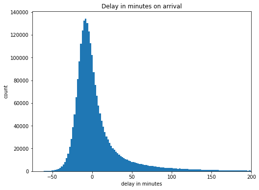

```python
bins=np.arange(fly.arr_delay.min(),fly.arr_delay.max()+2, 2)
plt.figure(figsize=(8,6))
plt.hist(data=fly, x='arr_delay', bins=bins)
plt.title('Delay in minutes on arrival')
plt.xlim(-75, 200)
plt.xlabel('delay in minutes')
plt.ylabel('count');
```

## Distribution of flights during day of week

You might be wondering if we can experience more delays in first half of the week, because data shows there is on average more flights from Monday to Thursday than from Friday to Sunday.

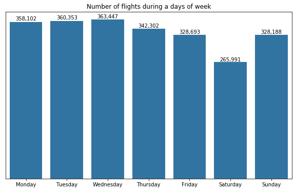

```python
fly['fl_day'] = fly['fl_date'].dt.day_name()


base_color = sns.color_palette()[0]
day_order = ['Monday', 'Tuesday', 'Wednesday', 'Thursday', 'Friday', 'Saturday', 'Sunday']
ordered_day = pd.api.types.CategoricalDtype(ordered=True, categories=day_order)
fly['fl_day'] = fly['fl_day'].astype(ordered_day)

plt.figure(figsize=(10,6))
ax = sns.countplot(data=fly, x='fl_day', color=base_color, order=day_order)
ax.set(yticks=[])
plt.title('Number of flights during a days of week')
plt.xlabel('')
plt.ylabel('')

for p in ax.patches:
    height = p.get_height()
    ax.text(p.get_x()+p.get_width()/2.,
            height * 1.01,
            "{:,.0f}".format(height),
            ha="center")
```

## Distribution of flights during hour of day

We can see that **airports are the most busy from 6:00 to 18:00, especially from 06:00 to 08:59**. You might assume these hours would gain more delays because of heavier workload for airport employees. We will see the answer little bit later.

Also it is worth to point out that from 00:00 to 04:59 there is very little number of flights when comparing to daily busy hours later.

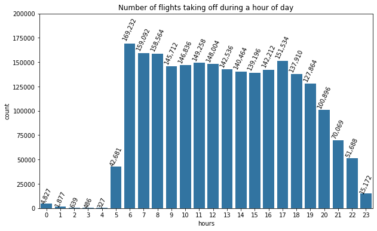

```python
fly['hour'] = pd.to_datetime(fly.crs_dep_time).dt.hour
plt.figure(figsize=(10,6))
ax = sns.countplot(data=fly, x='hour', color=base_color)
ax.grid(False)

for p in ax.patches:
    height = p.get_height()
    ax.text(p.get_x()+p.get_width()/2.,
            height * 1.02,
            "{:,}".format(height),
            ha="center", rotation=65)
plt.ylim(0, 200000)
plt.title('Number of flights taking off during a hour of day')
plt.xlabel('hours');
```

## Chance of big delay vs. hour of departure (absolute frequency)

More busy time of departure doesn't equal more chances for delay on arrival of the plane. Actually, **the most busy departure interval (from 06:00 to 08:59) does not result in more delays on landing**. Delays tend to increase volume from morning till they reach their maximum in absolute numbers between 17:00 to 20:00 and then start to decrease.

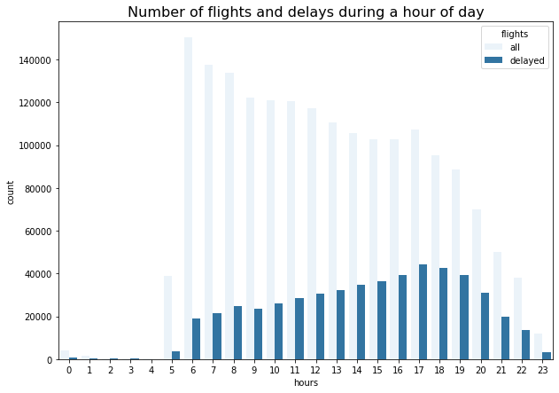

```python
plt.figure(figsize=(10,7))
ax = sns.countplot(data=fly, x='hour', hue='big_delay', color=base_color)
plt.title('Number of flights and delays during a hour of day', fontsize=16)
plt.xlabel('hours')
ax.grid(False)
l = plt.legend(title='flights')
l.get_texts()[0].set_text('all')
l.get_texts()[1].set_text('delayed');
```

## Chance of big delay vs. hour of departure (relative frequency)

Grouping hours per percentage of delayed flights indicates low percentage of delays in morning, slowly increasing over noon and afternoon, reaching maximum percentage of delays from 18:00 till 20:59. (Very early morning times were excluded because of low number of flights.)

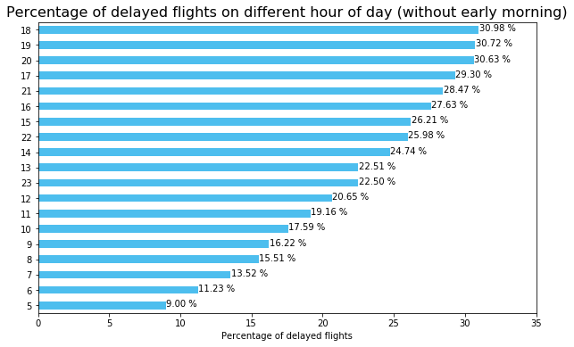

```python
fly_wo_morn = fly[fly['hour']>4]
h1_w = fly_wo_morn.groupby(['hour'])['big_delay'].count().to_frame(name = 'sum_all_flights').reset_index()
h2_w = fly_wo_morn.groupby(['hour'])['big_delay'].sum().to_frame(name = 'sum_delayed').reset_index()
h3_w = h1_w.merge(h2_w)
h3_w['%_delayed_of_all'] = h3_w['sum_delayed']*100/h3_w['sum_all_flights']
h3_w=h3_w.sort_values(by='%_delayed_of_all')
ax = h3_w.set_index(['hour'])['%_delayed_of_all'].plot(kind='barh', figsize=(10, 6), fontsize=10, color='#4DBEEE')

for p in ax.patches:
        percentage = '{:.2f} %'.format(p.get_width())
        x = p.get_x() + p.get_width() + 0.03
        y = p.get_y() + p.get_height()/3
        ax.annotate(percentage, (x, y), size=10)

plt.grid(False)
plt.xlim(0, 35)
plt.title('Percentage of delayed flights on different hour of day (without early morning)', fontsize=16)
plt.xlabel('Percentage of delayed flights', fontsize=10)
plt.ylabel('');
```

## Chance of big delay vs. day of week

Most flights are delayed on Mondays, the least on Saturdays. Suprising is that second most delays happen on Sundays, even though there is less flights on Sunday than on any weekday.

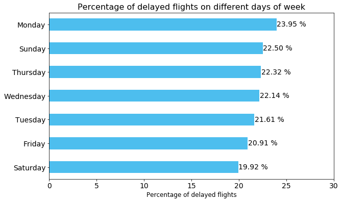

```python
d1 = fly.groupby(['fl_day'])['big_delay'].count().to_frame(name = 'sum_all_flights').reset_index()
d2 = fly.groupby(['fl_day'])['big_delay'].sum().to_frame(name = 'sum_delayed').reset_index()
d3 = d1.merge(d2)
d3['%_delayed_of_all'] = d3['sum_delayed']*100/d3['sum_all_flights']
d3=d3.sort_values(by='%_delayed_of_all')
ax = d3.set_index(['fl_day'])['%_delayed_of_all'].plot(kind='barh', figsize=(10, 6), fontsize=14, color='#4DBEEE')

for p in ax.patches:
        percentage = '{:.2f} %'.format(p.get_width())
        x = p.get_x() + p.get_width() + 0.03
        y = p.get_y() + p.get_height()/3
        ax.annotate(percentage, (x, y), size=14)

plt.grid(False)
plt.xlim(0, 30)
plt.title('Percentage of delayed flights on different days of week', fontsize=16)
plt.xlabel('Percentage of delayed flights', fontsize=12)
plt.ylabel('');
```

## Chance of big delay on day of week and hour of day

If you want to avoid delays, the worst time to take plane is from 18:00 till 20:59 on Monday or Sunday. The best time would be from 05:00 till 6:59 on any day, but especially Friday or Thursday.

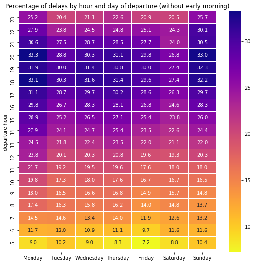

```python
hour_sorted = np.sort(fly.hour.unique())
del_pct_wo = pd.DataFrame(fly_wo_morn[fly_wo_morn['arr_delay_new']>14].groupby(['fl_day', 'hour'])['year'].count()*100/fly_wo_morn.groupby(['fl_day', 'hour'])['year'].count())
del_pct_hour_wo = del_pct_wo.unstack(level=0)
hour_sorted_wo = np.sort(fly_wo_morn.hour.unique())
plt.figure(figsize=(9,9))
ax = sns.heatmap(del_pct_hour_wo, annot=True, fmt="0.1f", linewidths=0.25, xticklabels=day_order, yticklabels=hour_sorted_wo, cmap="plasma_r")
ax.axes.set_title("Percentage of delays by hour and day of departure (without early morning)", fontsize=12)
ax.set(xlabel='', ylabel='departure hour')
plt.ylim(-0.25, 19);
```

## Average length of delay on day of week and hour of day

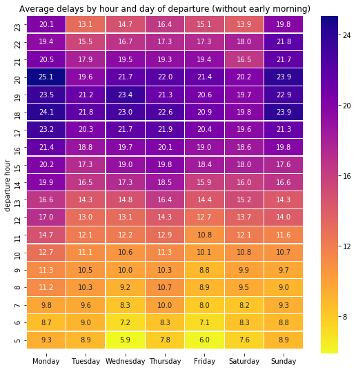

```python
del_avg_wo = pd.DataFrame(fly_wo_morn.groupby(['fl_day', 'hour'])['arr_delay_new'].mean())
del_avg_hour_wo = del_avg_wo.unstack(level=0)
plt.figure(figsize=(9, 9))
ax = sns.heatmap(del_avg_hour_wo, annot=True, fmt="0.1f", linewidths=0.25, xticklabels=day_order, yticklabels=hour_sorted_wo, cmap="plasma_r")
ax.axes.set_title("Average delays by hour and day of departure (without early morning)", fontsize=12)
ax.set(xlabel='', ylabel='departure hour')
plt.ylim(-0.25, 19);
```